# IF4202

# 1301180390

```python
import pandas as pd
import numpy as np
import matplotlib.pyplot as plt
import matplotlib as mpl
import seaborn as sns
import random as rd
from pandas.plotting import scatter_matrix
import seaborn as sns
import missingno as msno
import warnings
from matplotlib import style
from sklearn import datasets, linear_model
from sklearn.model_selection import train_test_split
from sklearn.impute import SimpleImputer
from sklearn.preprocessing import LabelEncoder, OneHotEncoder, MinMaxScaler
warnings.filterwarnings('ignore')
mpl.rcParams['figure.dpi'] = 100

!git clone https://github.com/andrewsihotang/tubesMLone.git
```

```
fatal: destination path 'tubesMLone' already exists and is not an empty directory.
```

```python
data1 = pd.read_csv('/content/tubesMLone/salju/salju_train.csv')
data1.shape
```

```
(109095, 24)
```

```python
data1.info()
```

```
<class 'pandas.core.frame.DataFrame'>
RangeIndex: 109095 entries, 0 to 109094
Data columns (total 24 columns):
 #   Column                    Non-Null Count   Dtype
---  ------                    --------------   -----
 0   id                        109095 non-null  int64
 1   Tanggal                   109095 non-null  object
 2   KodeLokasi                109095 non-null  object
 3   SuhuMin                   107973 non-null  float64
 4   SuhuMax                   108166 non-null  float64
 5   Hujan                     106664 non-null  float64
 6   Penguapan                 62071 non-null   float64
 7   SinarMatahari             56716 non-null   float64
 8   ArahAnginTerkencang       101351 non-null  object
 9   KecepatanAnginTerkencang  101399 non-null  float64
```

[output cut: 16 more lines]

```python
data1.dtypes
```

```
id                            int64
Tanggal                      object
KodeLokasi                   object
SuhuMin                     float64
SuhuMax                     float64
Hujan                       float64
Penguapan                   float64
SinarMatahari               float64
ArahAnginTerkencang          object
KecepatanAnginTerkencang    float64
ArahAngin9am                 object
ArahAngin3pm                 object
KecepatanAngin9am           float64
KecepatanAngin3pm           float64
Kelembaban9am               float64
Kelembaban3pm               float64
Tekanan9am                  float64
Tekanan3pm                  float64
Awan9am                     float64
Awan3pm                     float64
Suhu9am                     float64
Suhu3pm                     float64
BersaljuHariIni              object
BersaljuBesok                object
dtype: object
```

```python
data1.describe()
```

|  | id | SuhuMin | SuhuMax | Hujan | Penguapan | SinarMatahari | KecepatanAnginTerkencang | KecepatanAngin9am | KecepatanAngin3pm | Kelembaban9am | Kelembaban3pm | Tekanan9am | Tekanan3pm | Awan9am | Awan3pm | Suhu9am | Suhu3pm |
| --- | --- | --- | --- | --- | --- | --- | --- | --- | --- | --- | --- | --- | --- | --- | --- | --- | --- |
| count | 109095.000000 | 107973.000000 | 108166.000000 | 106664.000000 | 62071.000000 | 56716.000000 | 101399.000000 | 107742.000000 | 106792.000000 | 107093.000000 | 105721.000000 | 97768.000000 | 97787.000000 | 67251.000000 | 64624.000000 | 107755.000000 | 106397.000000 |
| mean | 54548.000000 | 12.196183 | 23.214819 | 2.385005 | 5.462440 | 7.599527 | 40.032002 | 14.052115 | 18.677579 | 68.895577 | 51.567626 | 1017.647080 | 1015.253117 | 4.450893 | 4.516140 | 16.991391 | 21.672771 |
| std | 31493.158146 | 6.389419 | 7.106596 | 8.588155 | 4.201638 | 3.789042 | 13.617554 | 8.926092 | 8.830199 | 18.995528 | 20.791573 | 7.117338 | 7.047875 | 2.884566 | 2.718738 | 6.477602 | 6.922833 |
| min | 1.000000 | -8.500000 | -4.800000 | 0.000000 | 0.000000 | 0.000000 | 7.000000 | 0.000000 | 0.000000 | 0.000000 | 0.000000 | 980.500000 | 977.100000 | 0.000000 | 0.000000 | -7.200000 | -5.400000 |
| 25% | 27274.500000 | 7.600000 | 17.900000 | 0.000000 | 2.600000 | 4.800000 | 31.000000 | 7.000000 | 13.000000 | 57.000000 | 37.000000 | 1012.900000 | 1010.400000 | 1.000000 | 2.000000 | 12.300000 | 16.600000 |
| 50% | 54548.000000 | 12.000000 | 22.600000 | 0.000000 | 4.800000 | 8.400000 | 39.000000 | 13.000000 | 19.000000 | 70.000000 | 52.000000 | 1017.600000 | 1015.200000 | 5.000000 | 5.000000 | 16.700000 | 21.100000 |
| 75% | 81821.500000 | 16.800000 | 28.200000 | 0.800000 | 7.400000 | 10.600000 | 48.000000 | 19.000000 | 24.000000 | 83.000000 | 66.000000 | 1022.400000 | 1020.000000 | 7.000000 | 7.000000 | 21.600000 | 26.400000 |
| max | 109095.000000 | 33.900000 | 47.300000 | 371.000000 | 145.000000 | 14.300000 | 135.000000 | 130.000000 | 87.000000 | 100.000000 | 100.000000 | 1041.000000 | 1039.600000 | 9.000000 | 9.000000 | 40.200000 | 46.700000 |

```python
data1.head()
```

|  | id | Tanggal | KodeLokasi | SuhuMin | SuhuMax | Hujan | Penguapan | SinarMatahari | ArahAnginTerkencang | KecepatanAnginTerkencang | ArahAngin9am | ArahAngin3pm | KecepatanAngin9am | KecepatanAngin3pm | Kelembaban9am | Kelembaban3pm | Tekanan9am | Tekanan3pm | Awan9am | Awan3pm | Suhu9am | Suhu3pm | BersaljuHariIni | BersaljuBesok |
| --- | --- | --- | --- | --- | --- | --- | --- | --- | --- | --- | --- | --- | --- | --- | --- | --- | --- | --- | --- | --- | --- | --- | --- | --- |
| 0 | 1 | 01/06/2014 | C4 | 10.4 | 15.5 | 4.8 | NaN | NaN | WSW | 24.0 | NaN | WSW | 0.0 | 13.0 | 78.0 | 76.0 | 1020.1 | 1018.5 | NaN | NaN | 13.1 | 15.0 | Ya | Tidak |
| 1 | 2 | 15/07/2014 | C10 | 9.0 | 17.0 | 8.0 | 2.6 | 7.4 | NaN | NaN | SW | WNW | 13.0 | 20.0 | 80.0 | 61.0 | 1015.2 | 1014.6 | 7.0 | 5.0 | 11.9 | 15.5 | Ya | Ya |
| 2 | 3 | 16/02/2011 | C46 | 18.2 | 32.0 | 0.0 | NaN | NaN | ESE | 44.0 | SE | SE | 15.0 | 26.0 | 62.0 | 42.0 | NaN | NaN | NaN | NaN | 23.8 | 29.6 | Tidak | Tidak |
| 3 | 4 | 08/08/2012 | C36 | 7.3 | 24.5 | 0.0 | 8.4 | 10.4 | SSW | 54.0 | N | SW | 13.0 | 19.0 | 25.0 | 17.0 | 1019.2 | 1016.9 | 1.0 | 7.0 | 15.3 | 23.2 | Tidak | Tidak |
| 4 | 5 | 29/10/2016 | C7 | 5.9 | 20.3 | 0.0 | 3.6 | 12.6 | N | 37.0 | NNW | ESE | 22.0 | 19.0 | 55.0 | 48.0 | 1019.7 | 1014.7 | 2.0 | 6.0 | 12.4 | 18.1 | Tidak | Tidak |

# PREPROCESSING

## Missing Value

```python
data1.isnull().sum()
```

```
id                              0
Tanggal                         0
KodeLokasi                      0
SuhuMin                      1122
SuhuMax                       929
Hujan                        2431
Penguapan                   47024
SinarMatahari               52379
ArahAnginTerkencang          7744
KecepatanAnginTerkencang     7696
ArahAngin9am                 7923
ArahAngin3pm                 3197
KecepatanAngin9am            1353
KecepatanAngin3pm            2303
Kelembaban9am                2002
Kelembaban3pm                3374
Tekanan9am                  11327
Tekanan3pm                  11308
Awan9am                     41844
Awan3pm                     44471
Suhu9am                      1340
Suhu3pm                      2698
BersaljuHariIni              2431
BersaljuBesok                2431
dtype: int64
```

```python
#cek missing value
total=data1.isnull().sum().sort_values(ascending = False)
print(total)
```

```
SinarMatahari               52379
Penguapan                   47024
Awan3pm                     44471
Awan9am                     41844
Tekanan9am                  11327
Tekanan3pm                  11308
ArahAngin9am                 7923
ArahAnginTerkencang          7744
KecepatanAnginTerkencang     7696
Kelembaban3pm                3374
ArahAngin3pm                 3197
Suhu3pm                      2698
Hujan                        2431
BersaljuBesok                2431
BersaljuHariIni              2431
KecepatanAngin3pm            2303
Kelembaban9am                2002
KecepatanAngin9am            1353
Suhu9am                      1340
SuhuMin                      1122
SuhuMax                       929
KodeLokasi                      0
Tanggal                         0
id                              0
dtype: int64
```

```python
data1.dropna(inplace=True)
data1.shape
```

```
(42411, 24)
```

```python
#remove data null
# data1 = data1.dropna(how='any',subset=['Penguapan','Hujan','SuhuMin','SuhuMax'])
data1.isnull().sum()
```

```
id                          0
Tanggal                     0
KodeLokasi                  0
SuhuMin                     0
SuhuMax                     0
Hujan                       0
Penguapan                   0
SinarMatahari               0
ArahAnginTerkencang         0
KecepatanAnginTerkencang    0
ArahAngin9am                0
ArahAngin3pm                0
KecepatanAngin9am           0
KecepatanAngin3pm           0
Kelembaban9am               0
Kelembaban3pm               0
Tekanan9am                  0
Tekanan3pm                  0
Awan9am                     0
Awan3pm                     0
Suhu9am                     0
Suhu3pm                     0
BersaljuHariIni             0
BersaljuBesok               0
dtype: int64
```

**convert cal menjadi numerical agar dapat dilihat korelasinya**

```python
cal = data1.dtypes==object
cal_col = data1.columns[cal].tolist()
data1[cal_col] = data1[cal_col].apply(lambda col: LabelEncoder().fit_transform(col))
data1[cal_col].head()
data1
```

|  | id | Tanggal | KodeLokasi | SuhuMin | SuhuMax | Hujan | Penguapan | SinarMatahari | ArahAnginTerkencang | KecepatanAnginTerkencang | ArahAngin9am | ArahAngin3pm | KecepatanAngin9am | KecepatanAngin3pm | Kelembaban9am | Kelembaban3pm | Tekanan9am | Tekanan3pm | Awan9am | Awan3pm | Suhu9am | Suhu3pm | BersaljuHariIni | BersaljuBesok |
| --- | --- | --- | --- | --- | --- | --- | --- | --- | --- | --- | --- | --- | --- | --- | --- | --- | --- | --- | --- | --- | --- | --- | --- | --- |
| 3 | 4 | 849 | 15 | 7.3 | 24.5 | 0.0 | 8.4 | 10.4 | 11 | 54.0 | 3 | 12 | 13.0 | 19.0 | 25.0 | 17.0 | 1019.2 | 1016.9 | 1.0 | 7.0 | 15.3 | 23.2 | 0 | 0 |
| 4 | 5 | 3188 | 23 | 5.9 | 20.3 | 0.0 | 3.6 | 12.6 | 3 | 37.0 | 6 | 2 | 22.0 | 19.0 | 55.0 | 48.0 | 1019.7 | 1014.7 | 2.0 | 6.0 | 12.4 | 18.1 | 0 | 0 |
| 5 | 6 | 1271 | 2 | 14.4 | 21.8 | 0.0 | 3.2 | 4.4 | 12 | 39.0 | 12 | 11 | 19.0 | 20.0 | 63.0 | 52.0 | 1016.1 | 1012.5 | 7.0 | 7.0 | 16.7 | 21.1 | 0 | 0 |
| 6 | 7 | 1380 | 15 | 7.7 | 18.7 | 0.2 | 5.6 | 9.7 | 14 | 46.0 | 7 | 14 | 19.0 | 28.0 | 69.0 | 31.0 | 1011.3 | 1008.8 | 1.0 | 1.0 | 11.3 | 18.3 | 0 | 0 |
| 8 | 9 | 1903 | 24 | 18.4 | 35.3 | 0.0 | 10.0 | 12.5 | 1 | 33.0 | 0 | 2 | 11.0 | 13.0 | 44.0 | 18.0 | 1017.9 | 1013.4 | 0.0 | 0.0 | 23.7 | 34.9 | 0 | 0 |
| ... | ... | ... | ... | ... | ... | ... | ... | ... | ... | ... | ... | ... | ... | ... | ... | ... | ... | ... | ... | ... | ... | ... | ... | ... |
| 109080 | 109081 | 232 | 18 | 16.8 | 34.1 | 0.0 | 12.8 | 10.3 | 1 | 85.0 | 1 | 1 | 30.0 | 37.0 | 48.0 | 28.0 | 1013.4 | 1009.2 | 1.0 | 4.0 | 25.6 | 33.0 | 0 | 0 |
| 109082 | 109083 | 2396 | 4 | 8.7 | 19.0 | 0.0 | 1.4 | 9.6 | 13 | 24.0 | 13 | 9 | 22.0 | 11.0 | 81.0 | 59.0 | 1024.6 | 1022.3 | 2.0 | 2.0 | 10.8 | 16.5 | 0 | 0 |
| 109088 | 109089 | 1877 | 6 | 14.3 | 26.2 | 0.0 | 8.0 | 12.6 | 5 | 50.0 | 7 | 4 | 13.0 | 33.0 | 51.0 | 37.0 | 1019.2 | 1015.6 | 0.0 | 2.0 | 21.1 | 25.5 | 0 | 0 |
| 109090 | 109091 | 3309 | 17 | 20.1 | 23.7 | 0.0 | 7.2 | 8.9 | 2 | 43.0 | 9 | 2 | 24.0 | 26.0 | 74.0 | 70.0 | 1019.3 | 1017.6 | 4.0 | 6.0 | 22.0 | 22.1 | 0 | 1 |
| 109093 | 109094 | 1696 | 1 | 10.8 | 29.8 | 0.0 | 7.8 | 11.2 | 0 | 48.0 | 2 | 9 | 13.0 | 26.0 | 35.0 | 18.0 | 1020.0 | 1015.8 | 0.0 | 1.0 | 21.7 | 29.2 | 0 | 0 |

42411 rows × 24 columns

**membandingkan keterkaitan**

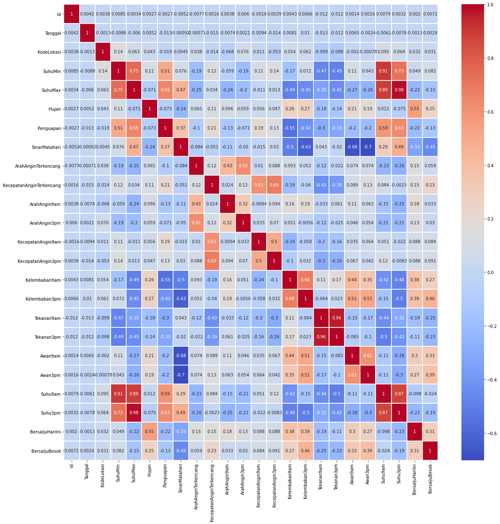

```python
plt.figure(figsize=(20,20))
sns.heatmap(data1.corr(),cmap='coolwarm',annot=True,linewidths=1);
```

```python
baru = ["BersaljuBesok", "SuhuMin", "SuhuMax", "Suhu9am", "Suhu3pm", "Penguapan", "SinarMatahari", "Awan9am", "Awan3pm", "Kelembaban9am", "Kelembaban3pm"]
newData = data1[baru]
newData.head()
newData
```

|  | BersaljuBesok | SuhuMin | SuhuMax | Suhu9am | Suhu3pm | Penguapan | SinarMatahari | Awan9am | Awan3pm | Kelembaban9am | Kelembaban3pm |
| --- | --- | --- | --- | --- | --- | --- | --- | --- | --- | --- | --- |
| 3 | 0 | 7.3 | 24.5 | 15.3 | 23.2 | 8.4 | 10.4 | 1.0 | 7.0 | 25.0 | 17.0 |
| 4 | 0 | 5.9 | 20.3 | 12.4 | 18.1 | 3.6 | 12.6 | 2.0 | 6.0 | 55.0 | 48.0 |
| 5 | 0 | 14.4 | 21.8 | 16.7 | 21.1 | 3.2 | 4.4 | 7.0 | 7.0 | 63.0 | 52.0 |
| 6 | 0 | 7.7 | 18.7 | 11.3 | 18.3 | 5.6 | 9.7 | 1.0 | 1.0 | 69.0 | 31.0 |
| 8 | 0 | 18.4 | 35.3 | 23.7 | 34.9 | 10.0 | 12.5 | 0.0 | 0.0 | 44.0 | 18.0 |
| ... | ... | ... | ... | ... | ... | ... | ... | ... | ... | ... | ... |
| 109080 | 0 | 16.8 | 34.1 | 25.6 | 33.0 | 12.8 | 10.3 | 1.0 | 4.0 | 48.0 | 28.0 |
| 109082 | 0 | 8.7 | 19.0 | 10.8 | 16.5 | 1.4 | 9.6 | 2.0 | 2.0 | 81.0 | 59.0 |
| 109088 | 0 | 14.3 | 26.2 | 21.1 | 25.5 | 8.0 | 12.6 | 0.0 | 2.0 | 51.0 | 37.0 |
| 109090 | 1 | 20.1 | 23.7 | 22.0 | 22.1 | 7.2 | 8.9 | 4.0 | 6.0 | 74.0 | 70.0 |
| 109093 | 0 | 10.8 | 29.8 | 21.7 | 29.2 | 7.8 | 11.2 | 0.0 | 1.0 | 35.0 | 18.0 |

42411 rows × 11 columns

## Outlier

[figure not shown]

```python
mpl.rcParams['figure.dpi'] = 100
plt.figure(figsize=(10,50))
f, axes = plt.subplots(1, 4)
sns.boxplot(y=newData["SuhuMin"],ax=axes[0]) #SuhuMin
sns.boxplot(y=newData["SuhuMax"],ax=axes[1]) #SuhuMax
sns.boxplot(y=newData["Suhu9am"],ax=axes[2]) #Suhu9am
sns.boxplot(y=newData["Suhu3pm"],ax=axes[3]) #Suhu3pm
plt.subplots_adjust(wspace=8)
```

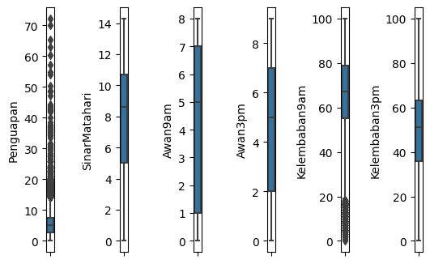

```python
mpl.rcParams['figure.dpi'] = 100
plt.figure(figsize=(10,50))
f, axes = plt.subplots(1, 6)
sns.boxplot(y=newData["Penguapan"],ax=axes[0]) #Penguapan
sns.boxplot(y=newData["SinarMatahari"],ax=axes[1]) #SinarMatahari
sns.boxplot(y=newData["Awan9am"],ax=axes[2]) #Awan9am
sns.boxplot(y=newData["Awan3pm"],ax=axes[3]) #Awan3pm
sns.boxplot(y=newData["Kelembaban9am"],ax=axes[4]) #Kelembaban9am
sns.boxplot(y=newData["Kelembaban3pm"],ax=axes[5]) #Kelembaban3pm
plt.subplots_adjust(wspace=8)
```

```python
newData.drop(newData[newData.SuhuMin < -5].index,inplace=True) #SuhuMin
newData.drop(newData[newData.SuhuMax > 40].index,inplace=True) #SuhuMax
newData.drop(newData[newData.Suhu9am > 37].index,inplace=True) #Suhu9am
newData.drop(newData[newData.Suhu3pm > 41].index,inplace=True) #Suhu3pm
newData.drop(newData[newData.Penguapan > 13].index,inplace=True) #Penguapan
newData.drop(newData[newData.Kelembaban9am < 20].index,inplace=True) #Kelembaban9am
newData
```

|  | BersaljuBesok | SuhuMin | SuhuMax | Suhu9am | Suhu3pm | Penguapan | SinarMatahari | Awan9am | Awan3pm | Kelembaban9am | Kelembaban3pm |
| --- | --- | --- | --- | --- | --- | --- | --- | --- | --- | --- | --- |
| 3 | 0 | 7.3 | 24.5 | 15.3 | 23.2 | 8.4 | 10.4 | 1.0 | 7.0 | 25.0 | 17.0 |
| 4 | 0 | 5.9 | 20.3 | 12.4 | 18.1 | 3.6 | 12.6 | 2.0 | 6.0 | 55.0 | 48.0 |
| 5 | 0 | 14.4 | 21.8 | 16.7 | 21.1 | 3.2 | 4.4 | 7.0 | 7.0 | 63.0 | 52.0 |
| 6 | 0 | 7.7 | 18.7 | 11.3 | 18.3 | 5.6 | 9.7 | 1.0 | 1.0 | 69.0 | 31.0 |
| 8 | 0 | 18.4 | 35.3 | 23.7 | 34.9 | 10.0 | 12.5 | 0.0 | 0.0 | 44.0 | 18.0 |
| ... | ... | ... | ... | ... | ... | ... | ... | ... | ... | ... | ... |
| 109080 | 0 | 16.8 | 34.1 | 25.6 | 33.0 | 12.8 | 10.3 | 1.0 | 4.0 | 48.0 | 28.0 |
| 109082 | 0 | 8.7 | 19.0 | 10.8 | 16.5 | 1.4 | 9.6 | 2.0 | 2.0 | 81.0 | 59.0 |
| 109088 | 0 | 14.3 | 26.2 | 21.1 | 25.5 | 8.0 | 12.6 | 0.0 | 2.0 | 51.0 | 37.0 |
| 109090 | 1 | 20.1 | 23.7 | 22.0 | 22.1 | 7.2 | 8.9 | 4.0 | 6.0 | 74.0 | 70.0 |
| 109093 | 0 | 10.8 | 29.8 | 21.7 | 29.2 | 7.8 | 11.2 | 0.0 | 1.0 | 35.0 | 18.0 |

40421 rows × 11 columns

**simpan dan export ke file bernama Nscaled_salju_train.csv**

```python
from google.colab import files

newData.to_csv('Nscaled_salju_train.csv')
files.download('Nscaled_salju_train.csv')
```

```python
# !pip install --upgrade gupload

# from pydrive.auth import GoogleAuth
# from google.colab import auth

# # Authenticate and create the PyDrive client
# auth.authenticate_user()

# !gupload --to '13mwhSIIJAgHy-zx_E1bomFCH-0TcBImt' Nscaled_salju_train.csv
```

**Menyeragamkan scaling pada tiap atribut**

```python
scalling=MinMaxScaler()
sclr=scalling.fit_transform(newData)
colNew=["BersaljuBesok", "SuhuMin", "SuhuMax", "Suhu9am", "Suhu3pm", "Penguapan","SinarMatahari", "Awan9am", "Awan3pm", "Kelembaban9am", "Kelembaban3pm"]
scalled=pd.DataFrame(sclr,columns=colNew)
scalled
```

|  | BersaljuBesok | SuhuMin | SuhuMax | Suhu9am | Suhu3pm | Penguapan | SinarMatahari | Awan9am | Awan3pm | Kelembaban9am | Kelembaban3pm |
| --- | --- | --- | --- | --- | --- | --- | --- | --- | --- | --- | --- |
| 0 | 0.0 | 0.352601 | 0.540059 | 0.431267 | 0.535411 | 0.646154 | 0.727273 | 0.125 | 0.777778 | 0.0625 | 0.161616 |
| 1 | 0.0 | 0.312139 | 0.415430 | 0.353100 | 0.390935 | 0.276923 | 0.881119 | 0.250 | 0.666667 | 0.4375 | 0.474747 |
| 2 | 0.0 | 0.557803 | 0.459941 | 0.469003 | 0.475921 | 0.246154 | 0.307692 | 0.875 | 0.777778 | 0.5375 | 0.515152 |
| 3 | 0.0 | 0.364162 | 0.367953 | 0.323450 | 0.396601 | 0.430769 | 0.678322 | 0.125 | 0.111111 | 0.6125 | 0.303030 |
| 4 | 0.0 | 0.673410 | 0.860534 | 0.657682 | 0.866856 | 0.769231 | 0.874126 | 0.000 | 0.000000 | 0.3000 | 0.171717 |
| ... | ... | ... | ... | ... | ... | ... | ... | ... | ... | ... | ... |
| 40416 | 0.0 | 0.627168 | 0.824926 | 0.708895 | 0.813031 | 0.984615 | 0.720280 | 0.125 | 0.444444 | 0.3500 | 0.272727 |
| 40417 | 0.0 | 0.393064 | 0.376855 | 0.309973 | 0.345609 | 0.107692 | 0.671329 | 0.250 | 0.222222 | 0.7625 | 0.585859 |
| 40418 | 0.0 | 0.554913 | 0.590504 | 0.587601 | 0.600567 | 0.615385 | 0.881119 | 0.000 | 0.222222 | 0.3875 | 0.363636 |
| 40419 | 1.0 | 0.722543 | 0.516320 | 0.611860 | 0.504249 | 0.553846 | 0.622378 | 0.500 | 0.666667 | 0.6750 | 0.696970 |
| 40420 | 0.0 | 0.453757 | 0.697329 | 0.603774 | 0.705382 | 0.600000 | 0.783217 | 0.000 | 0.111111 | 0.1875 | 0.171717 |

40421 rows × 11 columns

**simpan dan export ke file bernama scaled_salju_train.csv**

```python
from google.colab import files

scalled.to_csv('scaled_salju_train.csv')
files.download('scaled_salju_train.csv')
```

**cek korelasi kembali**

[figure not shown]

```python
plt.figure(figsize=(10,10))
sns.heatmap(scalled.corr(),cmap='coolwarm',annot=True,linewidths=1);
```

**Memilih atribut Awan3pm dan Kelembaban3pm karena memiliki nilai korelasi tertinggi terhadap atribut BersaljuBesok**

```python
scalled=pd.read_csv("scaled_salju_train.csv",usecols=["Awan3pm","Kelembaban3pm","BersaljuBesok"])
scalled
```

|  | BersaljuBesok | Awan3pm | Kelembaban3pm |
| --- | --- | --- | --- |
| 0 | 0.0 | 0.777778 | 0.161616 |
| 1 | 0.0 | 0.666667 | 0.474747 |
| 2 | 0.0 | 0.777778 | 0.515152 |
| 3 | 0.0 | 0.111111 | 0.303030 |
| 4 | 0.0 | 0.000000 | 0.171717 |
| ... | ... | ... | ... |
| 40416 | 0.0 | 0.444444 | 0.272727 |
| 40417 | 0.0 | 0.222222 | 0.585859 |
| 40418 | 0.0 | 0.222222 | 0.363636 |
| 40419 | 1.0 | 0.666667 | 0.696970 |
| 40420 | 0.0 | 0.111111 | 0.171717 |

40421 rows × 3 columns

```python
from google.colab import drive
drive.mount('/content/drive',force_remount=True)
```

```python
%cd ..
%cd /content/
```

```
/
/content
```

```python
scalled=pd.read_csv("scaled_salju_train.csv",usecols=["Awan3pm","Kelembaban3pm","BersaljuBesok"])
scalled
```

|  | BersaljuBesok | Awan3pm | Kelembaban3pm |
| --- | --- | --- | --- |
| 0 | 0.0 | 0.777778 | 0.161616 |
| 1 | 0.0 | 0.666667 | 0.474747 |
| 2 | 0.0 | 0.777778 | 0.515152 |
| 3 | 0.0 | 0.111111 | 0.303030 |
| 4 | 0.0 | 0.000000 | 0.171717 |
| ... | ... | ... | ... |
| 40416 | 0.0 | 0.444444 | 0.272727 |
| 40417 | 0.0 | 0.222222 | 0.585859 |
| 40418 | 0.0 | 0.222222 | 0.363636 |
| 40419 | 1.0 | 0.666667 | 0.696970 |
| 40420 | 0.0 | 0.111111 | 0.171717 |

40421 rows × 3 columns

```python
Nscalled=pd.read_csv("Nscaled_salju_train.csv",usecols=["Awan3pm","Kelembaban3pm","BersaljuBesok"])
Nscalled
```

|  | BersaljuBesok | Awan3pm | Kelembaban3pm |
| --- | --- | --- | --- |
| 0 | 0 | 7.0 | 17.0 |
| 1 | 0 | 6.0 | 48.0 |
| 2 | 0 | 7.0 | 52.0 |
| 3 | 0 | 1.0 | 31.0 |
| 4 | 0 | 0.0 | 18.0 |
| ... | ... | ... | ... |
| 40416 | 0 | 4.0 | 28.0 |
| 40417 | 0 | 2.0 | 59.0 |
| 40418 | 0 | 2.0 | 37.0 |
| 40419 | 1 | 6.0 | 70.0 |
| 40420 | 0 | 1.0 | 18.0 |

40421 rows × 3 columns

# CLUSTERING

**proses elbow**

```python
epsilon = list(range(5)) # Initialisation of epsilon
for k in range(1,6):
    cluster = pd.read_csv("scaled_salju_train.csv", usecols=["Awan3pm", "Kelembaban3pm"], nrows=20000) # Read data file into 'cluster'
    rows = cluster.shape[0] #contains the total number of rows in cluster data 'rows'
    cols = cluster.shape[1] #contains the total number of columns in cluster data 'cols'
    centroids = cluster.loc[np.random.randint(1,rows+1,k)] # Randomly initialises 'k' no. of centroids
    centroids['new'] = list(range(1,k+1)) # New indices 1 to k are set for the dataframe 'centroids'
    centroids.set_index('new',inplace = True)
    d = np.random.rand(rows) # Initialization of 'd' which would contain the centroid number closest to data point
    number_of_iterations = 15
    tmp_eps = list(range(number_of_iterations)) # 'tmp_eps' is the sum of squares of distances between points and centroid of a cluster for each iteration
    for i in range(0,number_of_iterations): # loop is for iterations
          for j in range(0,rows):
              d[j] = ((centroids - cluster.loc[j])**2).sum(axis = 1).idxmin()
          cluster['centroid number'] = d #new column 'centroid number' is added to dataframe 'cluster'
          MX = list(range(k)) # Initialisation of 'MX' which will store mean of 'x' values of each cluster
          MY = list(range(k)) # Initialisation of 'MY' which will store mean of 'y' values of each cluster
          for m in range(0,k):
              MX[m] = cluster[cluster['centroid number'] == (m+1)]['Awan3pm'].mean()
              MY[m] = cluster[cluster['centroid number'] == (m+1)]['Kelembaban3pm'].mean()
          centroids.replace(list(centroids['Awan3pm']),MX,inplace = True) # The 'centroids' are replaced with the new values
          centroids.replace(list(centroids['Kelembaban3pm']),MY,inplace = True) # The 'centroids' are replaced with the new values
          z = list(range(k)) # Initialisation of z and centroid of each cluster.
          for p in range(0,k): # loop calculates square of distances between data points and centroid of each cluster.
              z[p] = ((cluster[cluster['centroid number'] == p+1][['Awan3pm','Kelembaban3pm']] - centroids.iloc[p])**2).values.sum()
          tmp_eps[i] = sum(z)
          epsilon[k-1] = tmp_eps[i] # The cost function after final iteration for each value of 'k' would be stored in epsilon.
    %reset_selective -f centroids # The dataframe 'centroids' is reset.
```

[output not shown]

[output cut: 41 more lines]

[output not shown]

```python
print(epsilon) #cek nilai epsilon
```

```
[2448.384170676461, 895.2633686650431, 734.3420954055964, 3, 4]
```

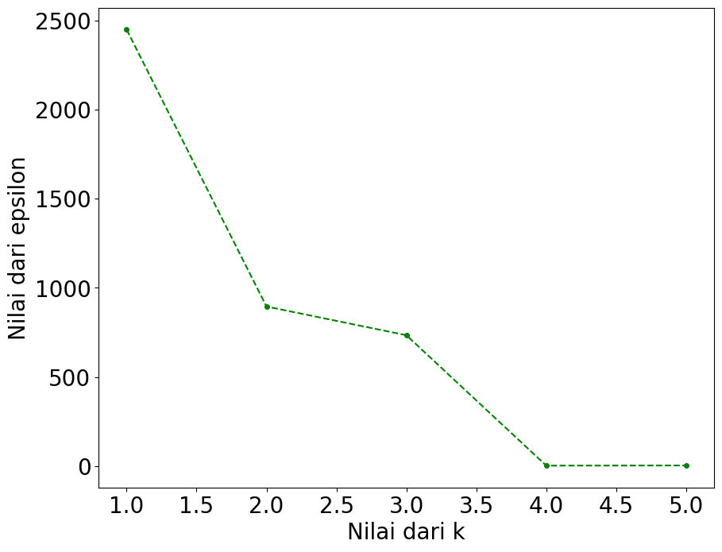

```python
k=list(range(1,6)) # range dari 'k'.
plt.figure(figsize=(10,8)) # size adjusted.
plt.xticks(fontsize=20) # size pada x-axis adjusted.
plt.yticks(fontsize=20) # size pada y-axis adjusted.
plt.plot(k,epsilon,'go--', linewidth=1.5, markersize=4) # Graph is plotted.
plt.xlabel('Nilai dari k',fontsize = 20) # x-axis.
plt.ylabel('Nilai dari epsilon',fontsize = 20) # y-axis.
```

**Mengkonversi dataframe ke dalam bentuk array agar lebih mudah diolah**

```python
#untuk data yang scale
Awan3pmScaled=scalled.Awan3pm #Scale Awan3pmScaled
Kelembaban3pmScaled=scalled.Kelembaban3pm #Scale Kelembaban3pmScaled
SaljuBesokScale=scalled.BersaljuBesok #Scale SaljuBesokScale
ScaleNew=[]
i=0
while i < len(scalled):
      DT1 = [Awan3pmScaled[i], Kelembaban3pmScaled[i], SaljuBesokScale[i]]
      ScaleNew.append(DT1)
      i += 1
```

```python
#untuk data yang unscale
Awan3pmNScaled=Nscalled.Awan3pm #Unscale Awan3pmNScaled
Kelembaban3pmNScaled=Nscalled.Kelembaban3pm #Unscale Kelembaban3pmNScaled
SaljuBesokNScale=Nscalled.BersaljuBesok #Unscale SaljuBesokNScale
NScaleNew=[]
i=0
while i < len(Nscalled):
      DT2=[Awan3pmNScaled[i],Kelembaban3pmNScaled[i],SaljuBesokNScale[i]]
      NScaleNew.append(DT2)
      i += 1
```

**untuk mencari nilai distance antara dua titik menggunakan fungsi manhattan distance**

```python
def Mdist(centroid, data): #manhattan distance
      Md=abs(float(centroid[0]-data[0]))+abs(float(centroid[1]-data[1]))
      return Md #return
```

**menentukan centroid baru pada setiap iterasi**

```python
def Cent(cluster):
      x=0 #initiate x
      y=0 #initiate y
      for i in range(len(cluster)):
            x=x+cluster[i][0]
            y=y+cluster[i][1]
      avgx=x/len(cluster)
      avgy=y/len(cluster)
      centroid=[avgx,avgy]
      return centroid
```

```python
def kmeans(dataset,maxitr):
      cent1=dataset[rd.randint(0,39744)]
      cnet2=dataset[rd.randint(0,39744)]
      minus=1
      itr=0
      while (minus!=0) and (itr<maxitr):
          cls1=[]
          cls2=[]
          cent1old=cent1
          cent2old=cnet2
          for j in range(len(dataset)):
              dist1=Mdist(cent1old,dataset[j])
              dist2=Mdist(cent2old,dataset[j])
              if dist1<dist2:
                  cls1.append(dataset[j])
              else:
                  cls2.append(dataset[j])
          cent1=Cent(cls1)
          cnet2=Cent(cls2)
          minus=(cent1[0]-cent1old[0])+(cent1[1]-cent1old[1])+(cnet2[0]-cent2old[0])+(cnet2[1]-cent2old[1])
          itr+=1
      centroids=[cent1, cnet2]
      return centroids,cls1,cls2
```

```python
SCent, scaledCluster1, scaledCluster2 = kmeans(ScaleNew, 100)
NSCent, unscaledCluster1, unscaledCluster2 = kmeans(NScaleNew, 100)
```

**scaled**

```python
c1AwanScale = [] #Scale
c1KelembabanScale = [] #Scale
c2AwanScale = [] #Scale
c2KelembabanScale = [] #Scale
for k in range(len(scaledCluster1)):
      c1AwanScale.append(scaledCluster1[k][0])
      c1KelembabanScale.append(scaledCluster1[k][1])
for l in range(len(scaledCluster2)):
      c2AwanScale.append(scaledCluster2[l][0])
      c2KelembabanScale.append(scaledCluster2[l][1])
```

**unscaled**

```python
c1AwanNScale = [] #Unscale
c1KelembabanNScale = [] #Unscale
c2AwanNScale = [] #Unscale
c2KelembabanNScale = [] #Unscale
for k in range(len(unscaledCluster1)):
      c1AwanNScale.append(unscaledCluster1[k][0])
      c1KelembabanNScale.append(unscaledCluster1[k][1])
for l in range(len(unscaledCluster2)):
      c2AwanNScale.append(unscaledCluster2[l][0])
      c2KelembabanNScale.append(unscaledCluster2[l][1])
```

**cls1 dan cls2 ke dalam bentuk grafik**

**visualisasi clustering yang sudah discaling**

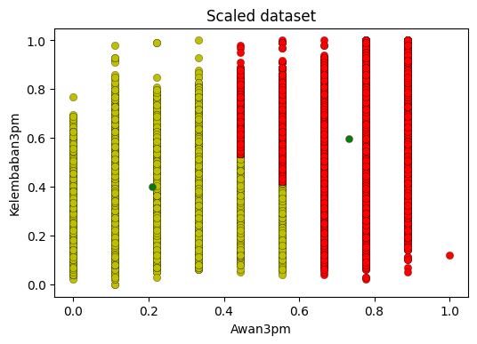

```python
plt.scatter(c1AwanScale,c1KelembabanScale,c='y',edgecolors='black',linewidth=0.20) #c1awankelembabanscale
plt.scatter(c2AwanScale,c2KelembabanScale,c='r',edgecolors='black',linewidth=0.20) #c2awankelembabanscale
plt.scatter(SCent[0][0],SCent[0][1],c ='g',edgecolors='magenta',linewidth=0.20) #scale centroid
plt.scatter(SCent[1][0],SCent[1][1],c ='g',edgecolors='magenta',linewidth=0.20) #scale centroid
plt.title('Scaled dataset') #title
plt.xlabel('Awan3pm') #xlabel
plt.ylabel('Kelembaban3pm') #ylabel
plt.show()
```

**visualisasi clustering yang belum discaling**

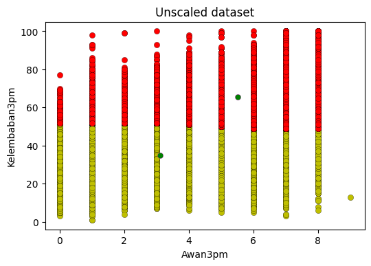

```python
plt.scatter(c1AwanNScale,c1KelembabanNScale,c='y',edgecolors='black',linewidth=0.20) #c1awankelembabanNscale
plt.scatter(c2AwanNScale,c2KelembabanNScale,c='r',edgecolors='black',linewidth=0.20) #c2awankelembabanNscale
plt.scatter(NSCent[0][0],NSCent[0][1],c ='g',edgecolors='magenta',linewidth=0.20) #Nscale centroid
plt.scatter(NSCent[1][0],NSCent[1][1],c ='g',edgecolors='magenta',linewidth=0.20) #Nscale centroid
plt.title('Unscaled dataset') #title
plt.xlabel('Awan3pm') #xlabel
plt.ylabel('Kelembaban3pm') #ylabel
plt.show()
```

**mengembalikan array dalam bentuk dataframe**

```python
c1AwanScale,c1KelembabanScale,scaledBersaljubesokc1=zip(*scaledCluster1) #cluster1scale
scaleCluster1=pd.DataFrame({'Awan3pm':c1AwanScale,'Kelembaban3pm':c1KelembabanScale},columns=['Awan3pm','Kelembaban3pm'])#cluster1scale
c2AwanScale,c2KelembabanScale,scaledBersaljubesokc2=zip(*scaledCluster2)#cluster2scale
scaleCluster2=pd.DataFrame({'Awan3pm':c2AwanScale,'Kelembaban3pm':c2KelembabanScale},columns=['Awan3pm','Kelembaban3pm']) #cluster2scale
```

```python
scaleCluster1['Cluster']='Tidak Bersalju' #cluster1scale
scaleCluster2['Cluster']='Bersalju' #cluster2scale
```

**Dataset yang sudah discaling dan clustering**

```python
scaleCluster=pd.concat([scaleCluster1,scaleCluster2],axis=0) #scaleCluster
scaleCluster
scaleCluster.groupby("Cluster").size() #scaleCluster size
```

[output not shown]

```python
c1AwanNScale,c1KelembabanNScale,unscaledBersaljubesokc1=zip(*unscaledCluster1) #cluster1Nscale
NscaleCluster1=pd.DataFrame({'Awan3pm':c1AwanNScale,'Kelembaban3pm':c1KelembabanNScale},columns=['Awan3pm','Kelembaban3pm']) #cluster1Nscale
c2AwanNScale,c2KelembabanNScale,unscaledBersaljubesokc2=zip(*unscaledCluster2) #cluster2Nscale
NscaleCluster2=pd.DataFrame({'Awan3pm':c2AwanNScale,'Kelembaban3pm':c2KelembabanNScale},columns=['Awan3pm','Kelembaban3pm']) #cluster2Nscale
```

```python
NscaleCluster1['Cluster'] = 'Tidak Bersalju' #cluster1Nscale
NscaleCluster2['Cluster'] = 'Bersalju' #cluster2Nscale
```

**Dataset yang belum discaling tapi sudah diclustering**

```python
NscaleCluster = pd.concat([NscaleCluster1, NscaleCluster2], axis=0) #NscaleCluster
NscaleCluster
NscaleCluster.groupby("Cluster").size() #NscaleCluster size
```

[output not shown]

**export data ke csv**

```python
scaleCluster.to_csv('ClusteringScalled.csv') #save to csv
NscaleCluster.to_csv('ClusteringUnscalled.csv') #save to csv
```

```python
files.download('ClusteringScalled.csv') #download csv
```

```python
files.download('ClusteringUnscalled.csv') #download csv
```